# Analysis of the Evolution of the Olympics in Recent History

Hristijan Marinkovski

6/9/2020

## Introduction

This document pertains to the analysis of a dataset which contains data about the olympics from from Athens 1896 to Rio 2016. It provides us with the opportunity to ask interesting questions regarding the developments within the olympics over near history.

Our goals will be to shine light on the changes that happeng during the recent history of the Olympics over time. The dataset encapsulates the entirety of the 20th century, which provides us with enough information to thoroughly check how the evolution of the Olympics happened during that time.

The 20th century was signified by cultural shifts, wars and developments, which makes this dataset particulary interesting for data analysis, as the scale of the shifts in the Olympics most likely resemble the drastic changes of the entire world during this period.

## Problem Description

We will try to pose multiple interesting questions regarding the evolution of the olympics using the data provided to us, and use data visualization and analysis to answer them. Our goal is to attept to draw interesting conclusions from this data and make predictions based on our analysis.

Given the heavy development of the world during the 20th century, any particularly interesting observations will also be noted, purely on the basis that they are interesting.

The questions we will try to answer using this dataset are the following:

- How has the number of participants in the Olympics changed over time, and can we find correlations between the number of participans and other factors?
- Which countries have had the most success in the Olympics? Do we have any outliers, and can we find correlations between the successful countries and other factors?
- How have the physical characteristics in the athletes evolved over time?
- How has gender participation in the olympics evolved over time? The end of the 20th century is noted for an increase of participation of women in male-dominated fields. Does this reflect on Olympic participation?

## Data Presentation

Like we noted previously, the dataset contains information regarding the Olympics from 1896 to 2016. The data was originally scraped from www.sports-reference.com, which hosts databases on Olympic history. I obtained this dataset from https://www.kaggle.com/

Firstly, we need to load the required libraries for further analysis.

```r
library(tidyverse)
library(readr)
library(skimr)
```

Now we may load athlete_events dataset.

```r
athlete_events <- read_csv("athlete_events.csv")
```

And quickly see how its constructed..

```r
head(athlete_events)
```

```
## # A tibble: 6 x 15
##      ID Name  Sex     Age Height Weight Team  NOC   Games  Year Season City
##   <dbl> <chr> <chr> <dbl>  <dbl>  <dbl> <chr> <chr> <chr> <dbl> <chr>  <chr>
## 1     1 A Di~ M        24    180     80 China CHN   1992~  1992 Summer Barc~
## 2     2 A La~ M        23    170     60 China CHN   2012~  2012 Summer Lond~
## 3     3 Gunn~ M        24     NA     NA Denm~ DEN   1920~  1920 Summer Antw~
## 4     4 Edga~ M        34     NA     NA Denm~ DEN   1900~  1900 Summer Paris
## 5     5 Chri~ F        21    185     82 Neth~ NED   1988~  1988 Winter Calg~
## 6     5 Chri~ F        21    185     82 Neth~ NED   1988~  1988 Winter Calg~
## # ... with 3 more variables: Sport <chr>, Event <chr>, Medal <chr>
```

We can quickly see that this part of the data contains information regarding information about the athletes and about their participations and results from different events. We can also note that certain values in the data set are NA, which we must take into consideration in future.

From looking at the head of the dataset we can see the columns are the following:

- ID
- Name
- Sex
- Age
- Height - Values are in centimeters.
- Weight - Values are in kilograms.
- Team - Country that was represented by the athlete.
- NOC - The National Olympics Commitee. They are responsible for the organization of their nations participations.
- Games
- Year
- Season
- Event
- Medal - NA values if no medal was won.

Next we can load and look at the noc_regions dataset.

```r
noc_regions <- read_csv("noc_regions.csv")
```

```r
head(noc_regions)
```

```
## # A tibble: 6 x 3
##   NOC   region      notes
##   <chr> <chr>       <chr>
## 1 AFG   Afghanistan <NA>
## 2 AHO   Curacao     Netherlands Antilles
## 3 ALB   Albania     <NA>
## 4 ALG   Algeria     <NA>
## 5 AND   Andorra     <NA>
## 6 ANG   Angola      <NA>
```

This dataset simply contains information concerning the regions and their comitees, hence it’s of limited use to us. We will mainly be focusing on working with the athlete_events data.

## Exploratory Data Analysis and Data Vizualization

### General Data Analysis and Statistics

Let’s focus on athlete_events since by observing the data in data presentation, it seems more useful for answering our proposed questions.

We can also quickly look at the structure of the dataset to help us in further subsetting and plotting:

```r
str(athlete_events)
```

```
## Classes 'spec_tbl_df', 'tbl_df', 'tbl' and 'data.frame': 271116 obs. of  15 variables:
##  $ ID    : num  1 2 3 4 5 5 5 5 5 5 ...
##  $ Name  : chr  "A Dijiang" "A Lamusi" "Gunnar Nielsen Aaby" "Edgar Lindenau Aabye" ...
##  $ Sex   : chr  "M" "M" "M" "M" ...
##  $ Age   : num  24 23 24 34 21 21 25 25 27 27 ...
##  $ Height: num  180 170 NA NA 185 185 185 185 185 185 ...
##  $ Weight: num  80 60 NA NA 82 82 82 82 82 82 ...
##  $ Team  : chr  "China" "China" "Denmark" "Denmark/Sweden" ...
##  $ NOC   : chr  "CHN" "CHN" "DEN" "DEN" ...
##  $ Games : chr  "1992 Summer" "2012 Summer" "1920 Summer" "1900 Summer" ...
##  $ Year  : num  1992 2012 1920 1900 1988 ...
##  $ Season: chr  "Summer" "Summer" "Summer" "Summer" ...
##  $ City  : chr  "Barcelona" "London" "Antwerpen" "Paris" ...
##  $ Sport : chr  "Basketball" "Judo" "Football" "Tug-Of-War" ...
##  $ Event : chr  "Basketball Men's Basketball" "Judo Men's Extra-Lightweight" "Football Men's Football" "Tug-Of-War Men's Tug-Of-War" ...
##  $ Medal : chr  NA NA NA "Gold" ...
##  - attr(*, "spec")=
##   .. cols(
##   ..   ID = col_double(),
##   ..   Name = col_character(),
##   ..   Sex = col_character(),
##   ..   Age = col_double(),
##   ..   Height = col_double(),
##   ..   Weight = col_double(),
##   ..   Team = col_character(),
##   ..   NOC = col_character(),
##   ..   Games = col_character(),
##   ..   Year = col_double(),
##   ..   Season = col_character(),
##   ..   City = col_character(),
##   ..   Sport = col_character(),
##   ..   Event = col_character(),
##   ..   Medal = col_character()
##   .. )
```

Now lets look at a summary of the main statistics of the dataset:

```r
skim(athlete_events)
```

Data summary

| Name | athlete_events |
| --- | --- |
| Number of rows | 271116 |
| Number of columns | 15 |
| _______________________ |  |
| Column type frequency: |  |
| character | 10 |
| numeric | 5 |
| ________________________ |  |
| Group variables | None |

**Variable type: character**

| skim_variable | n_missing | complete_rate | min | max | empty | n_unique | whitespace |
| --- | --- | --- | --- | --- | --- | --- | --- |
| Name | 0 | 1.00 | 2 | 108 | 0 | 134731 | 0 |
| Sex | 0 | 1.00 | 1 | 1 | 0 | 2 | 0 |
| Team | 0 | 1.00 | 2 | 47 | 0 | 1184 | 0 |
| NOC | 0 | 1.00 | 3 | 3 | 0 | 230 | 0 |
| Games | 0 | 1.00 | 11 | 11 | 0 | 51 | 0 |
| Season | 0 | 1.00 | 6 | 6 | 0 | 2 | 0 |
| City | 0 | 1.00 | 4 | 22 | 0 | 42 | 0 |
| Sport | 0 | 1.00 | 4 | 25 | 0 | 66 | 0 |
| Event | 0 | 1.00 | 15 | 85 | 0 | 765 | 0 |
| Medal | 231333 | 0.15 | 4 | 6 | 0 | 3 | 0 |

**Variable type: numeric**

| skim_variable | n_missing | complete_rate | mean | sd | p0 | p25 | p50 | p75 | p100 | hist |
| --- | --- | --- | --- | --- | --- | --- | --- | --- | --- | --- |
| ID | 0 | 1.00 | 68248.95 | 39022.29 | 1 | 34643 | 68205 | 102097.2 | 135571 | ▇▇▇▇▇ |
| Age | 9474 | 0.97 | 25.56 | 6.39 | 10 | 21 | 24 | 28.0 | 97 | ▇▃▁▁▁ |
| Height | 60171 | 0.78 | 175.34 | 10.52 | 127 | 168 | 175 | 183.0 | 226 | ▁▂▇▂▁ |
| Weight | 62875 | 0.77 | 70.70 | 14.35 | 25 | 60 | 70 | 79.0 | 214 | ▃▇▁▁▁ |
| Year | 0 | 1.00 | 1978.38 | 29.88 | 1896 | 1960 | 1988 | 2002.0 | 2016 | ▁▂▃▆▇ |

Hence, another interesting question is to consider how the amount of sports in the Olympics has changed over time, and whether there were any interesting sports that stand out in history, but aren’t available today.

There are also other interesting observations here, such as age,weight,height statistics etc.

We can clearly see from the structure and statistics that NA is the value of the medal column if the participant did not win any medal,it would be cleaner for further data analysis that we replace the NA’s with a more sensical value.

```r
athlete_events = athlete_events %>% mutate(Medal = if_else(is.na(Medal), "None", Medal))
```

The other NA values shouldn’t give us troubles in further analysis.

While these statistics are interesting and give us an understanding about the data, they’re mainly just general observations about the data, and not really specific enough for our questions. Hence, let’s attempt to analize the data in regards to the questions we proposed.

### Data Analysis and Statistics regarding our proposed questions.

**The first topic we were curious about was: How has the number of participants in the Olympics changed over time, and can we find correlations between the number of participans and other factors?**

Firstly, let’s see how many participants were in the Olympics yearly:

```r
  numb_of_participants = athlete_events %>%
  group_by(Year) %>%
  summarize(
    Athletes = length(unique(ID))
  )
```

```r
head(numb_of_participants)
```

```
## # A tibble: 6 x 2
##    Year Athletes
##   <dbl>    <int>
## 1  1896      176
## 2  1900     1224
## 3  1904      650
## 4  1906      841
## 5  1908     2024
## 6  1912     2409
```

```r
tail(numb_of_participants)
```

```
## # A tibble: 6 x 2
##    Year Athletes
##   <dbl>    <int>
## 1  2006     2494
## 2  2008    10899
## 3  2010     2536
## 4  2012    10517
## 5  2014     2745
## 6  2016    11179
```

Simply from viewing and comparing the head and tail of the dataframe, we can note that the number of participants has most likely increased over time. Lets further analize this by finding the average change of the number of participans over the years.

```r
numb_of_participants = numb_of_participants %>% mutate(lag = lag(Athletes))
numb_of_participants[1,3] = 0
increase = numb_of_participants %>% mutate(increase= Athletes-lag) %>% summarize(mean(increase))
print(increase)
```

```
## # A tibble: 1 x 1
##   `mean(increase)`
##              <dbl>
## 1             319.
```

We can see that the number of participants over time has definately increased. The average increase yearly is 319 participations.

Let’s see how that reflects on the diferent seasonal Olympics.

```r
  summer_counts = athlete_events %>% filter(Season=="Summer") %>%group_by(Year) %>% summarise(Athletes = length(unique(ID)))
  summer_counts = summer_counts %>% mutate(lag = lag(Athletes))
  summer_counts[1,3] = 0
  summer_increase = summer_counts %>% mutate(increase= Athletes-lag) %>% summarize(mean(increase))

  winter_counts = athlete_events %>% filter(Season=="Winter") %>%group_by(Year) %>% summarise(Athletes = length(unique(ID)))
  winter_counts = winter_counts %>% mutate(lag = lag(Athletes))
  winter_counts[1,3] = 0
  winter_increase = winter_counts %>% mutate(increase= Athletes-lag) %>% summarize(mean(increase))

  print(summer_increase)
```

```
## # A tibble: 1 x 1
##   `mean(increase)`
##              <dbl>
## 1             385.
```

```r
  print(winter_increase)
```

```
## # A tibble: 1 x 1
##   `mean(increase)`
##              <dbl>
## 1             125.
```

We see that the average increase in participants yearly is much higher in the summer olympics than it is in the winter. So we have found a correlation between the rising popularity of the summer olympics and the increase in participants in the olympics over the 20th century.

It is obvious that an overall increase is prevelant, however, it is still interesting to see how the increases or decreases in the number of participants changes during troubling events in the 20th century, such as the two world wars and the great depression. However, further analysis will require data plotting. So, let us plot the number of athletes that competed yearly in both the summer and winter olympics.

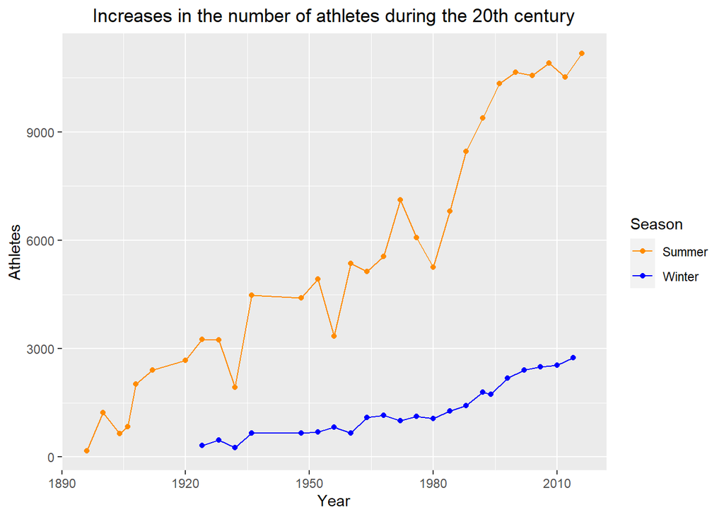

```r
athletecounts <- athlete_events %>%
  group_by(Year, Season) %>%
  summarize(Athletes = length(unique(ID)))

ggplot(athletecounts, aes(x=Year, y=Athletes, group=Season, color=Season)) +
  geom_line() +
  geom_point(size=1.5)+
  scale_color_manual(values=c("darkorange","blue"))+
  ggtitle("Increases in the number of athletes during the 20th century")+
  theme(plot.title = element_text(hjust = 0.5))
```

The above plot further shows us the massive difference in participation in the summer versus the winter olympics. We also notice that there are significant dips in pariticipation, especially in the summer olympics in 1932,1956,1976 and 1980.

With some research on events during these years, we easily learn that all of these dips in participation were caused by socio-economic reasons such as economic crisis’ or political boycots. The two world wars however,surprisingly show no significant changes in participation during the summer or winter olympics.

**The second topic we were interested in was: Which countries have had the most success in the Olympics? Do we have any outliers, and can we find correlations between the successful countries and other factors?**

Firstly ,lets see which country has the highest amount of medalists.

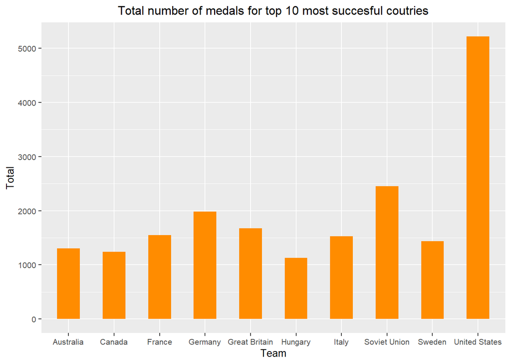

```r
medals_by_country = athlete_events %>% filter(Medal != "None")%>%
  group_by(Team, Medal) %>%
  summarize(Count=length(Medal)) %>%
  group_by(Team) %>%
  summarize(Total=sum(Count)) %>%
  arrange(desc(Total))

ggplot(medals_by_country[0:10,],aes(x=Team, y=Total))+
  geom_col(width = 0.5,fill = "darkorange")+
  ggtitle("Total number of medals for top 10 most succesful coutries")+
  theme(plot.title = element_text(hjust = 0.5),text = element_text(size = 10))
```

We can see from the above plot, the top 10 most successful countries in the olympics by the total number of medals won. Its quite obvious that the USA is far ahead of any other country in sheer number of medals.

While it’s clear that the USA is the most succesful country in the olympics during the entire period, it would be an interesting question to ask whether this is the trend during during the period around WW2, since Nazy Germany had immense cultural and economic influence during that period.

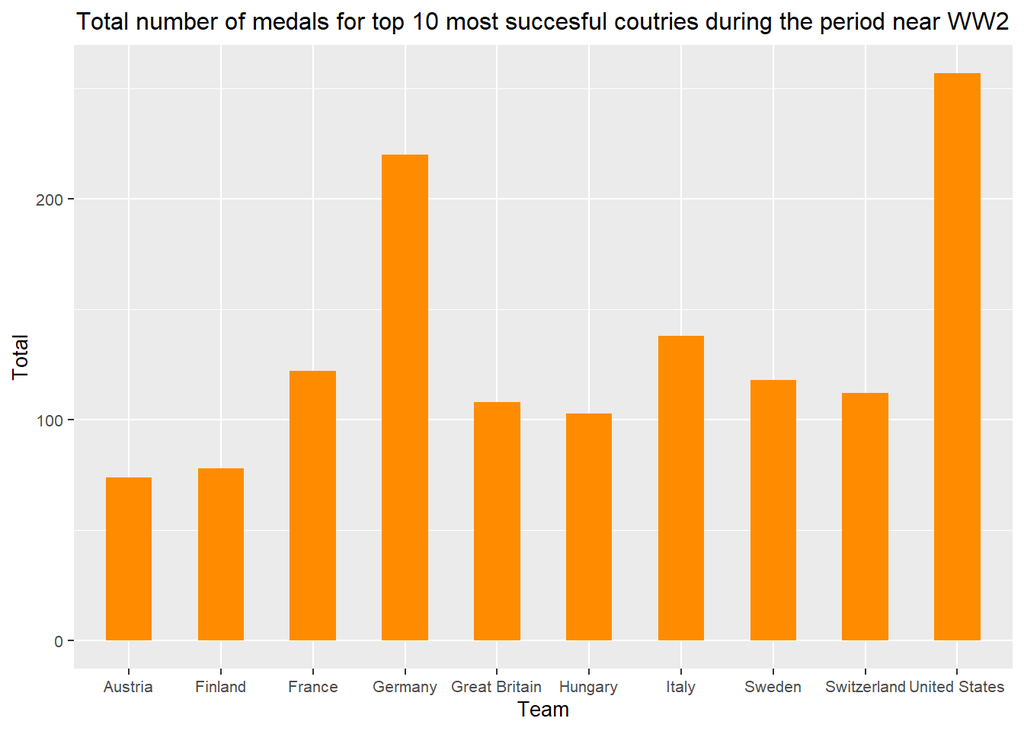

```r
medals_by_country = athlete_events %>% filter(Medal != "None",(Year==1936 | Year==1948))%>%
  group_by(Team, Medal) %>%
  summarize(Count=length(Medal)) %>%
  group_by(Team) %>%
  summarize(Total=sum(Count)) %>%
  arrange(desc(Total))

ggplot(medals_by_country[0:10,],aes(x=Team, y=Total))+
  geom_col(width = 0.5,fill = "darkorange")+
  ggtitle("Total number of medals for top 10 most succesful coutries during the period near WW2")+
  theme(plot.title = element_text(hjust = 0.5),text = element_text(size = 10))
```

**The third topic we wanted to expore was: How have the physical characteristics in the athletes evolved over time?**

To answer this, let’s look at the data for height and weight over the years.

```r
  heights_by_year = athlete_events %>%
  group_by(Year) %>%
  summarize(
    Average_Height = mean(Height,na.rm=TRUE)
  )
```

```r
head(heights_by_year)
```

```
## # A tibble: 6 x 2
##    Year Average_Height
##   <dbl>          <dbl>
## 1  1896           173.
## 2  1900           177.
## 3  1904           176.
## 4  1906           178.
## 5  1908           178.
## 6  1912           177.
```

```r
tail(heights_by_year)
```

```
## # A tibble: 6 x 2
##    Year Average_Height
##   <dbl>          <dbl>
## 1  2006           175.
## 2  2008           176.
## 3  2010           175.
## 4  2012           176.
## 5  2014           175.
## 6  2016           176.
```

From the above data, surprisingly we see that the average heights during the first few years of the olympics, and the last few years, are quite similar. Lets see if there are any outliers in history by plotting the data.

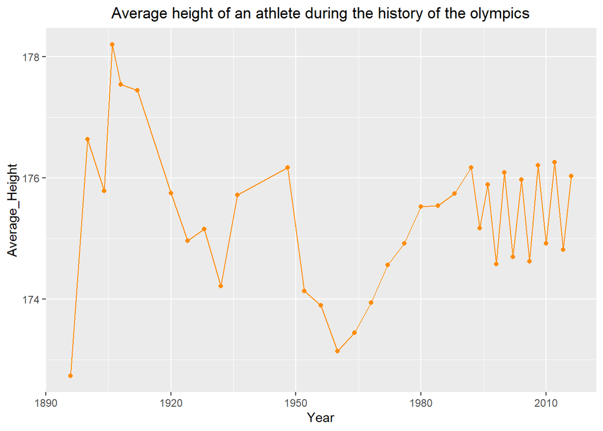

```r
ggplot(heights_by_year, aes(x=Year, y=Average_Height)) +
  geom_line(color="darkorange") +
  geom_point(size=1.5,color="darkorange")+
  ggtitle("Average height of an athlete during the history of the olympics")+
  theme(plot.title = element_text(hjust = 0.5))
```

We can see from our line graph that the average height of an atlete in the olympics over the last ~100 years had been relatively the same. It seems that the average height has always been between 170cm and 180cm. Although in certain periods such as the 1910’s the height has been a few cm higher, the difference is not huge.

Let’s see if the same trend applies to the average weight.

```r
  weights_by_year = athlete_events %>%
  group_by(Year) %>%
  summarize(
    Average_Weight = mean(Weight,na.rm=TRUE)
  )
```

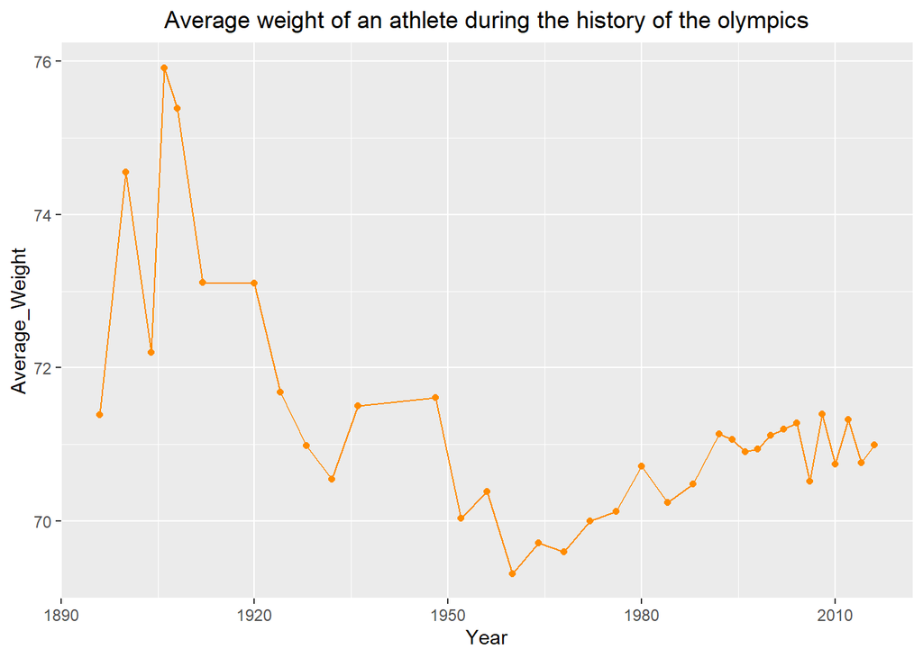

```r
ggplot(weights_by_year, aes(x=Year, y=Average_Weight)) +
  geom_line(color="darkorange") +
  geom_point(size=1.5,color="darkorange")+
  ggtitle("Average weight of an athlete during the history of the olympics")+
  theme(plot.title = element_text(hjust = 0.5))
```

Interestingly, it seems the data tells a similar story for the weight as well. The weight of the average olympian has remained reletively stangant over the years. While they have been some higher peaks during the eariler years of the olympics, no significant changes have occured since then.

**The last topic we wanted to expore was: How has gender participation in the olympics evolved over time? The end of the 20th century is noted for an increase of participation of women in male-dominated fields. Does this reflect on total Olympic participation?**

Firstly, lets see how participations between the two genders compare in the olympics in total.

```r
num_females = athlete_events %>% filter(Sex=="F") %>% summarise(Count = length(unique(ID)))
num_males = athlete_events %>% filter(Sex=="M") %>% summarise(Count = length(unique(ID)))
print(num_males)
```

```
## # A tibble: 1 x 1
##    Count
##    <int>
## 1 101590
```

```r
print(num_females)
```

```
## # A tibble: 1 x 1
##   Count
##   <int>
## 1 33981
```

We can see that there are around 3 times more males that competed during the history of the olympics. However, our initial hypothesis which we wanted to answer is how participation of women trended over the history, not what the total participation was. Hence, let’s plot the data of participation of women in olympics over time.

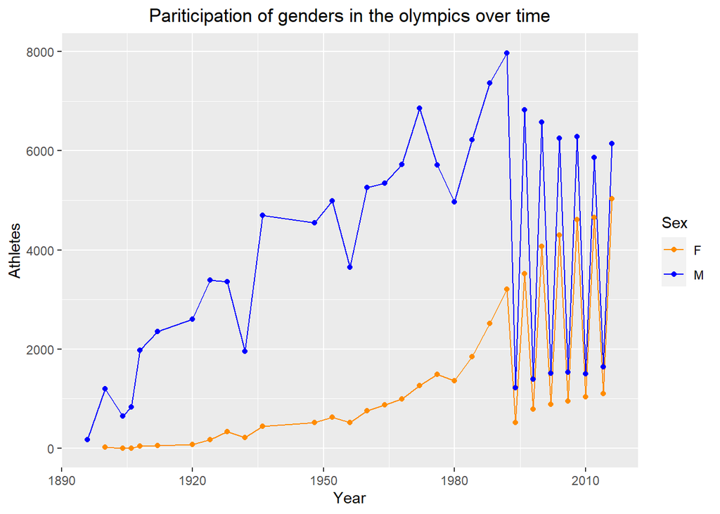

```r
counts_of_participants <- athlete_events %>%
  group_by(Year, Sex) %>%
  summarize(Athletes = length(unique(ID)))

ggplot(counts_of_participants, aes(x=Year, y=Athletes, group=Sex, color=Sex)) +
  geom_line() +
  geom_point(size=1.5)+
  scale_color_manual(values=c("darkorange","blue"))+
  ggtitle("Pariticipation of genders in the olympics over time")+
  theme(plot.title = element_text(hjust = 0.5))
```

Another interesting observation that we can see here is that women did not participate in the olympics of 1896. Their first appeareance was in the subsequent olympics in 1900.

We can also notice that while the increase in women’s participation is apparent, so is the increase in men’s participation. During the highest increases in women’s participation, men’s participation declines. Hence, there is no obvious correlation between the increase of women participating in the olympics and the overall number of participations in the olympics.

## Interpretation/Conclusion

We conclude the following for our proposed questions:

Although we reached our conclusions regarding our initially proposed questions, this dataset is incredibly interesting and many further questions could be asked about it.

We mainly focused on questions we were initially interested in, but there are many other topics to touch upon such as participations of nations in different events, changes in the events themselves, statistics about athletes in specific events etc.

## References

“Exploratory Data Analysis (Eda) Using Python | Python Data Analysis | Python Training | Edureka.” n.d. https://www.youtube.com/watch?v=-o3AxdVcUtQ&.

“Exploratory Data Analysis in R: Towards Data Understanding.” n.d. https://www.youtube.com/watch?v=JW5Ug6NQexg.

Peng, Roger. 2015. *R Programming for Data Science*. Leanpub.

“R: Exploratory Data Analysis (Eda), Univariate Analysis.” n.d. https://www.youtube.com/watch?v=ONrGJF_8onw.